# 双振子

22920242203150 2025-9-5

课程代码均在如下 GitHub 仓库开源：https://github.com/GHe0000/scientific-programming-intro

## 目录

## 作业要求

- 总结解析求解简谐双振子的过程，并用数值结果验证之
- 验证简谐双振子中 $Q_1$ 上的能量与 $Q_2$ 上的能量不会随时间变化
- 分以下两种情况分别计算 $E_0=0.001, 0.1, 0.5$ 时的庞加莱截面和最大李雅普诺夫指数
1. $\alpha=0, \beta=1$
2. $\alpha=2, \beta = 1$.

### 解析求解简谐双振子

#### 问题定义

记势能函数为:

$$ V(x) = \frac 1 2 k x^2 + \frac 1 3 \alpha x^3 + \frac 1 4 \beta x^4 $$

对于双振子，有哈密顿量如下：

$$ H = \frac{p_1^2}{2m_1} + \frac{p_2^2}{2m_2} + V(x_1) + V(-x_2) + V(x_2 - x_1) $$

哈密顿量不显含时间，因此系统能量守恒（无论是线性还是非线性的情况均成立）

对于简谐双振子，有 $\alpha=\beta=0$

#### 求解

(这一部分的处理过程主要参考 刘川, 理论力学. §4 小振动 中多自由度系统的简谐振动的处理)

上述哈密顿量有正则方程：

$$ \begin{cases} \dot{x_1} = \frac{\partial H}{\partial p_1} = \frac{p_1}{m} \\ \dot{x_2} = \frac{\partial H}{\partial p_2} = \frac{p_2}{m} \\ \dot{p_1} = -\frac{\partial H}{\partial x_1} = -2 k x_1 + k x_2 \\ \dot{p_2} = -\frac{\partial H}{\partial x_2} = -2 k x_2 + k x_1 \\ \end{cases} $$

上述方程可以化成：

$$ \begin{cases} m \ddot{x_1} + 2k x_1 - k x_2 = 0 \\ m \ddot{x_2} + 2k x_2 - k x_1 = 0 \end{cases} $$

记 $x=(x_1,x_2)^T$，上述方程可以写为：

$$ M \ddot x + K x = 0 $$

其中：

$$ M = \begin{pmatrix} m & \\ & m \end{pmatrix},\quad K = \begin{pmatrix} 2k & -k \\ -k & 2k \end{pmatrix} $$

取试探解 $x=ae^{-i\omega t}$，则上述方程变为：

$$ (K-\omega^2 M)a = 0 $$

这实际上变成了一个求解本征值和本征向量的问题. 要求 $a$ 有非零解，即：

$$\det (K-\omega^2 M) = 0$$

即：

$$ 2k - m \omega^2 = \pm k $$

解得：

$$ \omega_1 = \sqrt{k/m}, \quad \omega_2 = \sqrt{3k/m} $$

其对应的本征向量为：

$$ a_1 = \frac{1}{2}(1,1)^T, \quad a_2 = \frac{1}{2} (1,-1)^T $$

从而得到模态矩阵：$A=(a_1,a_2)$. 模态矩阵给出了广义坐标 $x$ 与简正坐标 $Q$ 之间的变换关系：

$$ Q = A^{-1} x $$

从而有：

$$ \begin{aligned} Q_1 = x_1 + x_2, \quad & Q_2 = x_1 - x_2 \\ x_1 = \frac 1 2 (Q_1 + Q_2), \quad & x_2 = \frac 1 2 (Q_1 - Q_2) \end{aligned} $$

由于 $Q_1,Q_2$ 正交（线性代数，不同特征值），因此两者独立，各自以 $\omega_1,\omega_2$ 振动，因此：

$$ \begin{aligned} Q_1 &= A_1 \cos (\omega_1 t + \phi_1) \\ Q_2 &= A_2 \cos (\omega_2 t + \phi_2) \end{aligned} $$

为了方便，我们不妨假设 $x_1 = x_2 = 0$，因此 $Q_1 = Q_2 = 0$. 设初始动量分别为 $p_1,p_2$.

又因为：

$$ \begin{aligned} \dot{Q_1} = \frac 1 {m} (p_1 + p_2) \\ \dot{Q_2} = \frac 1 {m} (p_1 - p_2) \end{aligned} $$

求解 $A_1,A_2$，得：

$$ A_1 = \frac{1}{\omega_1} \left( \frac{p_1 + p_2}{m} \right) $$ $$ A_2 = \frac{1}{\omega_2} \left( \frac{p_1 - p_2}{m} \right) $$

综上，我们完整求解了简谐双振子（初始位移均为 $0$）：

$$ \begin{aligned} x_1 = \frac 1 2 (Q_1 + Q_2), \quad & x_2 = \frac 1 2 (Q_1 - Q_2) \end{aligned} $$

$$ \begin{aligned} Q_1 &= A_1 \cos (\omega_1 t + \phi_1) \\ Q_2 &= A_2 \cos (\omega_2 t + \phi_2) \end{aligned} $$

其中：

$$ \omega_1 = \sqrt{k/m}, \quad \omega_2 = \sqrt{3k/m} $$

$$ A_1 = \frac{1}{\omega_1} \left( \frac{p_1 + p_2}{m} \right) $$ $$ A_2 = \frac{1}{\omega_2} \left( \frac{p_1 - p_2}{m} \right) $$

#### 作用量-角量表示

现在我们有简正坐标 $Q_1,Q_2$，我们希望求出其共轭动量，保证其仍然满足正则方程.

我们设：

$$ \begin{aligned} P_1 = a p_1 + b p_2 \\ P_2 = c p_1 + d p_2 \end{aligned} $$

根据哈密顿力学的中的要求，我们需要 $P_1,P_2,Q_1,Q_2$ 满足泊松括号 $[Q_i,P_j] = \delta_ij$，$[Q_i,Q_j]=[P_i,P_j]=0$. 其中：

$$ [Q_i,P_j] = \sum_{k=1}^2 \frac{\partial Q_i}{\partial x_k}\frac{\partial P_j}{\partial p_k} - \frac{\partial Q_i}{\partial p_k}\frac{\partial P_j}{\partial x_k} $$

注意到 $\partial_{p_k} Q_i = \partial_{x_k} P_i =0$. 因此：

- $a+b=1$
- $c+d=0$
- $a-b=0$
- $c-d=1$

解得：$a=b=c=-d=1/2$

因此：

$$ \begin{aligned} P_1 = \frac 1 2 (p_1 + p_2) \\ P_2 = \frac 1 2 (p_1 - p_2) \end{aligned} $$

此时哈密顿量用 $P_1,P_2,Q_1,Q_2$ 表示：

$$ H = H_1 + H_2 $$

其中

$$ \begin{aligned} H_1 = \frac{P_1^2}{m} + \frac{k}{4} Q_1^2 \\ H_2 = \frac{P_2^2}{m} + \frac{3k}{4} Q_2^2 \end{aligned} $$

对于 $H_1$，类似上一次作业谐振子，有：

$$ I_1 = \frac{1}{2\pi} \oint P_1 d Q_1 = \frac{E_1}{\omega_1},\quad \theta_1 = \omega_1 t $$

其中 $E_1$ 为第一个简正模的能量：$E_1 = P_1^2/m + k Q_1^2 / 4$

同理：

$$ I_2 = \frac{E_2}{\omega_2} \quad, \theta_2 = \omega_2 t $$

其中 $E_2$ 为第二个简正模的能量：$E_2 = P_2^2/m + 3 k Q_2^2/4$

显然，对于简谐的情况，两个简正模的能量不会发生变化.

#### 数值验证

这里我们先导入需要的库，并针对 Jupyter Notebook 进行一些设置.

其中：

$$ V'(x) = k x + \alpha x^2 + \beta x^3 $$

$$ \begin{aligned} f_1 = -\frac{\partial H}{\partial x_1} = -V'(x_1) + V'(x_2 - x_1) \\ f_1 = -\frac{\partial H}{\partial x_2} = V'(-x_2) - V'(x_2 - x_1) \end{aligned} $$

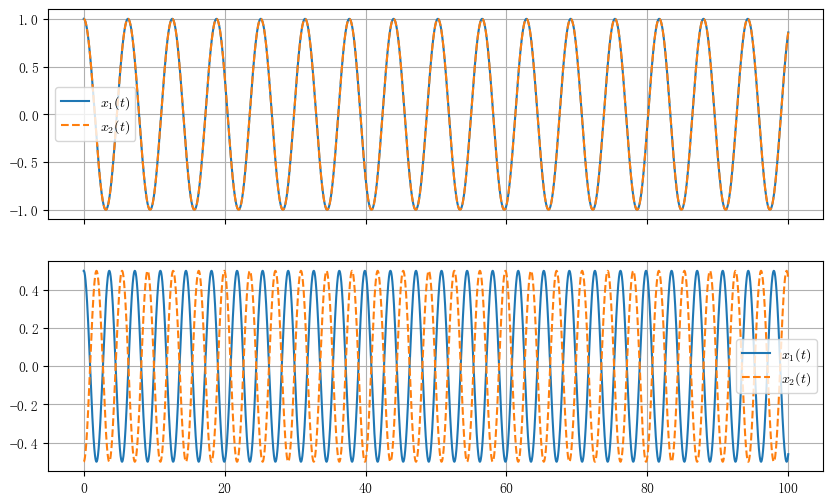

### 定义

由于在 $(Q_1,Q_2,P_1,P_2)$ 中计算比较方便，因此下面我们迭代使用 $(Q_1,Q_2,P_1,P_2)$ 作为坐标.

注意此时（将哈密顿量用新坐标表示）：

$$ H = \frac{P_1^2}{m} + \frac{P_2^2}{m} + \frac{Q_{1}^{4} \beta}{32} + \frac{3 Q_{1}^{2} Q_{2}^{2} \beta}{16} + \frac{Q_{1}^{2} Q_{2} \alpha}{4} + \frac{Q_{1}^{2} k}{4} + \frac{9 Q_{2}^{4} \beta}{32} - \frac{Q_{2}^{3} \alpha}{4} + \frac{3 Q_{2}^{2} k}{4} $$

$$ \frac{\partial V}{\partial Q_1} = \frac{Q_{1}^{3} \beta}{8} + \frac{3 Q_{1} Q_{2}^{2} \beta}{8} + \frac{Q_{1} Q_{2} \alpha}{2} + \frac{Q_{1} k}{2} $$

$$ \frac{\partial V}{\partial Q_2} = \frac{3 Q_{1}^{2} Q_{2} \beta}{8} + \frac{Q_{1}^{2} \alpha}{4} + \frac{9 Q_{2}^{3} \beta}{8} - \frac{3 Q_{2}^{2} \alpha}{4} + \frac{3 Q_{2} k}{2} $$

## 结论

### 解析求解简谐双振子

## 参考资料

## 致谢

## 附一：问题

## 附二：学习心得